# Project-Denver Crime

# Step-6: Change in Crime: Visualizations

```r
crime.categories.yearly$TOTAL <- rowSums(crime.categories.yearly[,2:6])
crime.categories.yearly <- crime.categories.yearly[order(crime.categories.yearly$TOTAL, decreasing = TRUE),]
rownames(crime.categories.yearly) <- NULL

pandoc.header('6A: Crime figures over the years', 1, 'setext')
```

# 6A: Crime figures over the years

```r
pander(crime.categories.yearly[,c(1,2,3,4,5,6,8)], justify = c("left"))#Category and year wise crime figures
```

| OFFENSE_CATEGORY_ID | 2014 | 2015 | 2016 | 2017 | 2018 | TOTAL |
| --- | --- | --- | --- | --- | --- | --- |
| traffic-accident | 21395 | 23307 | 23739 | 24255 | 24282 | 116978 |
| all-other-crimes | 15270 | 15729 | 16465 | 17233 | 17607 | 82304 |
| public-disorder | 9832 | 9793 | 9915 | 9355 | 8569 | 47464 |
| larceny | 9190 | 8895 | 9099 | 8940 | 9212 | 45336 |
| theft-from-motor-vehicle | 5013 | 6262 | 6571 | 7341 | 8116 | 33303 |
| drug-alcohol | 5968 | 6186 | 6085 | 5673 | 6132 | 30044 |
| auto-theft | 3448 | 4480 | 4835 | 5549 | 5362 | 23674 |
| burglary | 4463 | 4877 | 4681 | 4444 | 4098 | 22563 |
| other-crimes-against-persons | 4053 | 4408 | 4633 | 4765 | 4091 | 21950 |
| aggravated-assault | 1743 | 2007 | 2151 | 2099 | 2438 | 10438 |
| white-collar-crime | 1036 | 1312 | 1189 | 1267 | 1275 | 6079 |
| robbery | 1057 | 1213 | 1155 | 1204 | 1207 | 5836 |
| sexual-assault | 584 | 717 | 724 | 862 | 828 | 3715 |
| arson | 127 | 107 | 95 | 126 | 114 | 569 |
| murder | 32 | 57 | 54 | 58 | 57 | 258 |

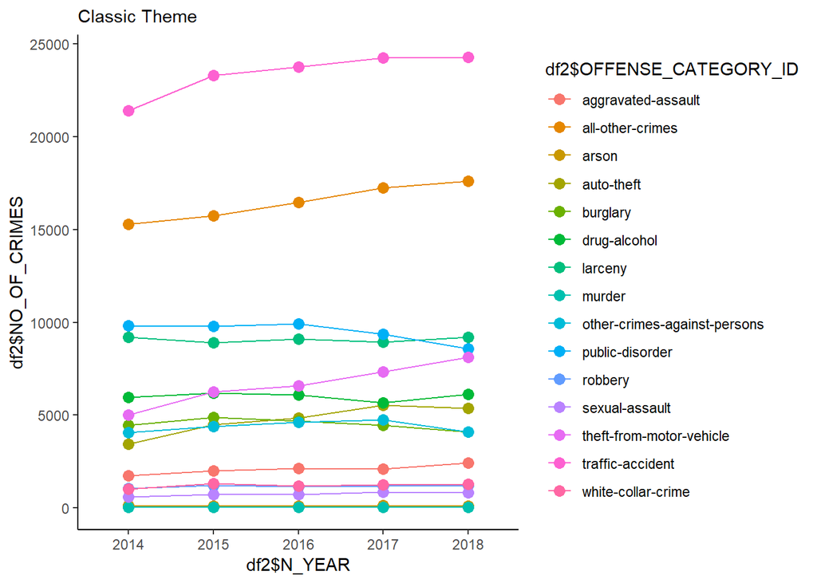

```r
#Add labels
df2 <- crime.cat.yr[crime.cat.yr$N_YEAR != 2019,]
ggplot(df2, aes(x=df2$N_YEAR, y=df2$NO_OF_CRIMES)) +
  geom_line(aes(colour=df2$OFFENSE_CATEGORY_ID, group=df2$OFFENSE_CATEGORY_ID)) +
  geom_point(aes(colour=df2$OFFENSE_CATEGORY_ID), size=3)+  scale_fill_brewer(palette="Set1") +
    theme_classic() +
    labs(subtitle="Classic Theme")
```

```r
cat("\\newpage")
```

Step-7:Change in Crimes: Category Wise

```r
###############::NO-6::##################
pandoc.header('Step-7: Category wise Change in Crimes', 1, 'setext')
```

# Step-7: Category wise Change in Crimes

```r
#The change in crime of the top 5 categories between 2017 and 2018 is as below:-
off.cat.change <- crime.categories.yearly[,c(1,5,6)]
off.cat.change$OFFENSE_CATEGORY_ID <- as.character(off.cat.change$OFFENSE_CATEGORY_ID)
off.cat.change$N_PERCENT_CHANGE <- round(((off.cat.change$`2018`- off.cat.change$`2017`)/off.cat.change$`2017`)*100,2)
off.cat.change <- off.cat.change[order(off.cat.change$N_PERCENT_CHANGE),]
off.cat.change$STATUS <- ifelse(off.cat.change$N_PERCENT_CHANGE < 0, "Crime Improved", "Crime Worsened")

rownames(off.cat.change) <- NULL
pandoc.header('7A: Five Categories where crime has improved', 1, 'setext')
```

# 7A: Five Categories where crime has improved

```r
pander(off.cat.change[1:5,], justify=c("left"))#Top Five categoris where crim has risen least or reduced.
```

| OFFENSE_CATEGORY_ID | 2017 | 2018 | N_PERCENT_CHANGE | STATUS |
| --- | --- | --- | --- | --- |
| other-crimes-against-persons | 4765 | 4091 | -14.14 | Crime Improved |
| arson | 126 | 114 | -9.52 | Crime Improved |
| public-disorder | 9355 | 8569 | -8.4 | Crime Improved |
| burglary | 4444 | 4098 | -7.79 | Crime Improved |
| sexual-assault | 862 | 828 | -3.94 | Crime Improved |

```r
off.cat.change.tmp <- off.cat.change[order(off.cat.change$N_PERCENT_CHANGE, decreasing = TRUE),]
#off.cat.change.tmp <- off.cat.change[order(off.cat.change$N_PERCENT_CHANGE),]
rownames(off.cat.change.tmp) <- NULL
pandoc.header('7B: Five Categories where crime has worsened', 1, 'setext')
```

# 7B: Five Categories where crime has worsened

```r
pander(off.cat.change.tmp[1:5,], justify=c("left"), include.rownames = FALSE)#Top Five categoris where crim has risen maximum.
```

| OFFENSE_CATEGORY_ID | 2017 | 2018 | N_PERCENT_CHANGE | STATUS |
| --- | --- | --- | --- | --- |
| aggravated-assault | 2099 | 2438 | 16.15 | Crime Worsened |
| theft-from-motor-vehicle | 7341 | 8116 | 10.56 | Crime Worsened |
| drug-alcohol | 5673 | 6132 | 8.09 | Crime Worsened |
| larceny | 8940 | 9212 | 3.04 | Crime Worsened |
| all-other-crimes | 17233 | 17607 | 2.17 | Crime Worsened |

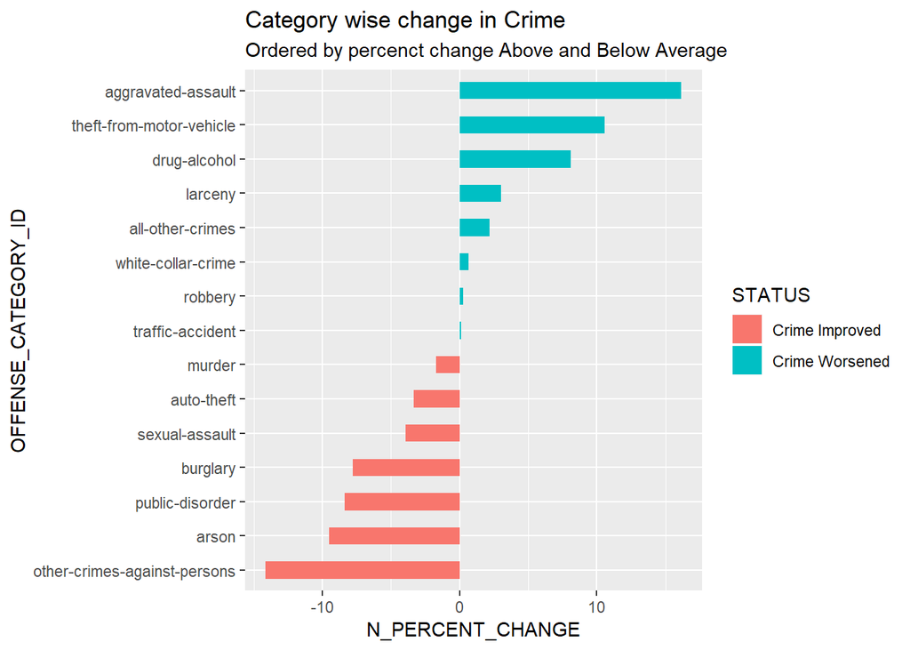

```r
rm(off.cat.change.tmp)

off.cat.change <- off.cat.change[order(off.cat.change$N_PERCENT_CHANGE),]
off.cat.change$OFFENSE_CATEGORY_ID <- factor(off.cat.change$OFFENSE_CATEGORY_ID, levels = off.cat.change$OFFENSE_CATEGORY_ID)

ggplot(off.cat.change, aes(x=OFFENSE_CATEGORY_ID, y=N_PERCENT_CHANGE)) +
  geom_bar(stat = 'identity', aes(fill = STATUS), width = .5) +
  labs(title="Category wise change in Crime",
       subtitle= "Ordered by percenct change Above and Below Average", xlab = "Gap from Average", ylab ="aa") +
  coord_flip()
```

```r
cat("\\newpage")
```

Step-8:Change in Crimes: Precinct Wise

```r
###############::NO-8::##################
pandoc.header('Step-8: Precinct wise Change in Crime', 1, 'setext')
```

# Step-8: Precinct wise Change in Crime

```r
crime.data.precint <- crime.data[crime.data$N_YEAR=="2017",]
crime.precints.change <- data.frame(tapply(crime.data.precint$DISTRICT_ID, crime.data.precint$PRECINCT_ID, length))
crime.precints.change$PRECINT_ID <- row.names(crime.precints.change)
crime.precints.change$Y2017 <- crime.precints.change$tapply.crime.data.precint.DISTRICT_ID..crime.data.precint.PRECINCT_ID..
crime.precints.change <- crime.precints.change[,2:3]
rownames(crime.precints.change) <- rep(1:nrow(crime.precints.change))

crime.data.precint <- crime.data[crime.data$N_YEAR=="2018",]
crime.precints.tmp <- data.frame(tapply(crime.data.precint$DISTRICT_ID, crime.data.precint$PRECINCT_ID, length))
crime.precints.tmp$Y2018 <- crime.precints.tmp$tapply.crime.data.precint.DISTRICT_ID..crime.data.precint.PRECINCT_ID..

crime.precints.change <- cbind(crime.precints.change, crime.precints.tmp$Y2018)
colnames(crime.precints.change) <- c("PRECINCT_ID", "2017", "2018")

crime.precints.change$N_PERCENT_CHANGE <- round(((crime.precints.change$`2018`- crime.precints.change$`2017`)/crime.precints.change$`2017`)*100,2)
crime.precints.change$STATUS <- ifelse(crime.precints.change$N_PERCENT_CHANGE<0, "Crime Reduced", "Crime Increased")
crime.precints.change <- crime.precints.change[order(crime.precints.change$N_PERCENT_CHANGE),]
crime.precints.change$PRECINCT_ID <- factor(crime.precints.change$PRECINCT_ID, levels = crime.precints.change$PRECINCT_ID)

rownames(crime.precints.change) <- NULL
pandoc.header('8A: Five Precints where crime has improved maximum', 1, 'setext')
```

# 8A: Five Precints where crime has improved maximum

```r
pander(crime.precints.change[1:5,])#Pricints with max increase in crime
```

| PRECINCT_ID | 2017 | 2018 | N_PERCENT_CHANGE | STATUS |
| --- | --- | --- | --- | --- |
| 211 | 2860 | 2446 | -14.48 | Crime Reduced |
| 411 | 2447 | 2126 | -13.12 | Crime Reduced |
| 223 | 3333 | 2963 | -11.1 | Crime Reduced |
| 222 | 1888 | 1748 | -7.42 | Crime Reduced |
| 212 | 2086 | 1945 | -6.76 | Crime Reduced |

```r
crime.precints.tmp <- crime.precints.change[order(crime.precints$NO_OF_CRIMES, decreasing = TRUE),]# Precinsts with leaste crime
rownames(crime.precints.tmp) <- NULL
pandoc.header('8B: Five Precints where crime has increased the most', 1, 'setext')
```

# 8B: Five Precints where crime has increased the most

```r
pander(crime.precints.tmp[1:5,])#Pricints with max crime
```

| PRECINCT_ID | 2017 | 2018 | N_PERCENT_CHANGE | STATUS |
| --- | --- | --- | --- | --- |
| 522 | 1119 | 1565 | 39.86 | Crime Increased |
| 523 | 1000 | 1157 | 15.7 | Crime Increased |
| 314 | 1509 | 1730 | 14.65 | Crime Increased |
| 512 | 2484 | 2815 | 13.33 | Crime Increased |
| 511 | 1932 | 2184 | 13.04 | Crime Increased |

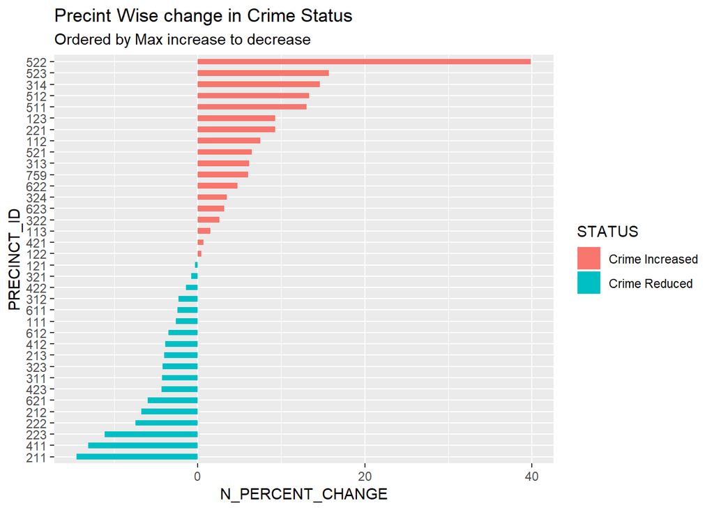

```r
rm(crime.precints.tmp)

##check labels
ggplot(crime.precints.change, aes(x=PRECINCT_ID, y=N_PERCENT_CHANGE, label="Status")) +
  geom_bar(stat = 'identity', aes(fill = STATUS), width = .5) +
  labs(title="Precint Wise change in Crime Status",
       subtitle= "Ordered by Max increase to decrease", xlab = "Gap from Average", ylab ="aa") +
  coord_flip()
```

```r
cat("\\newpage")
```

Step-9:Change in Crimes: Month and Year Wise

```r
###############::NO-9::##################
pandoc.header('Step-9: Change in Crimes Month Wise and Year Wise', 1, 'setext')
```

# Step-9: Change in Crimes Month Wise and Year Wise

```r
cat('The Change in Crime month wise is being shown for last five years')
```

The Change in Crime month wise is being shown for last five years

```r
df.tmp.2 <- data.frame(tapply(crime.data$OFFENSE_CATEGORY_ID, crime.data$N_OCCURRENCE_DATE, length))
df.tmp.2$N_OCCURENCE_DATE <- as.Date(rownames(df.tmp.2))
df.tmp.2$N_NO_OF_INCIDENTS <- df.tmp.2$tapply.crime.data.OFFENSE_CATEGORY_ID..crime.data.N_OCCURRENCE_DATE..
df.tmp.2 <- df.tmp.2[,-1]
df.tmp.2$N_MONTH <- month(df.tmp.2$N_OCCURENCE_DATE)

crime.month.plot <- function(yr.1, yr.2){
  cat('The Change in Crime month wise is being shown for ', yr.1, 'and ', yr.2)
  df.tmp.3 <- df.tmp.2[year(df.tmp.2$N_OCCURENCE_DATE) == yr.1 | year(df.tmp.2$N_OCCURENCE_DATE) == yr.2 ,]
  cr.mt.plot <-  ggplot(df.tmp.3, aes(x=N_OCCURENCE_DATE, y=N_NO_OF_INCIDENTS, colour = factor(N_MONTH)))+geom_point()+
  facet_wrap(~year(N_OCCURENCE_DATE), nrow=1, scales = "free")+
  guides(colour=guide_legend(override.aes = list(size=4))) +
  theme_classic() + theme(axis.text.x=element_text(angle = 90, hjust = 0))+
    stat_smooth(method = "gam", formula = y~s(x,k=100), colour ="dodgerblue4", se=FALSE, size = 1.2)+
    labs(subtitle="Classic Theme")
  cr.mt.plot
}
pandoc.header('9A: Change in Crimes Month Wise and Year Wise', 1, 'setext')
```

# 9A: Change in Crimes Month Wise and Year Wise

```r
crime.month.plot(2014, 2015)
```

The Change in Crime month wise is being shown for 2014 and 2015

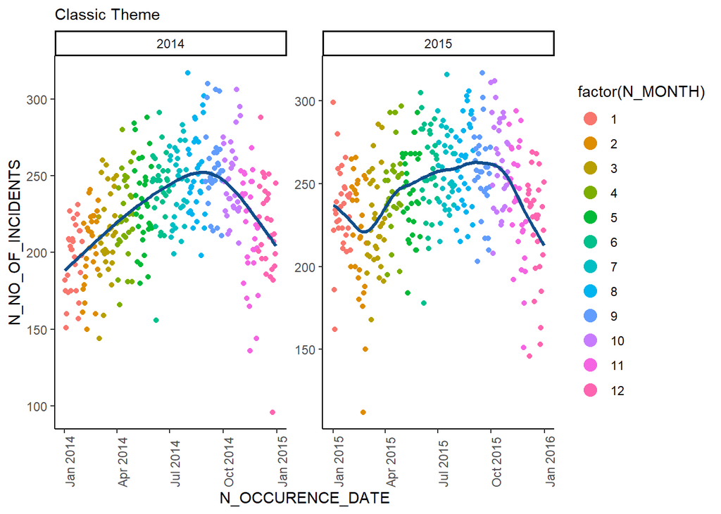

```r
crime.month.plot(2016, 2017)
```

The Change in Crime month wise is being shown for 2016 and 2017

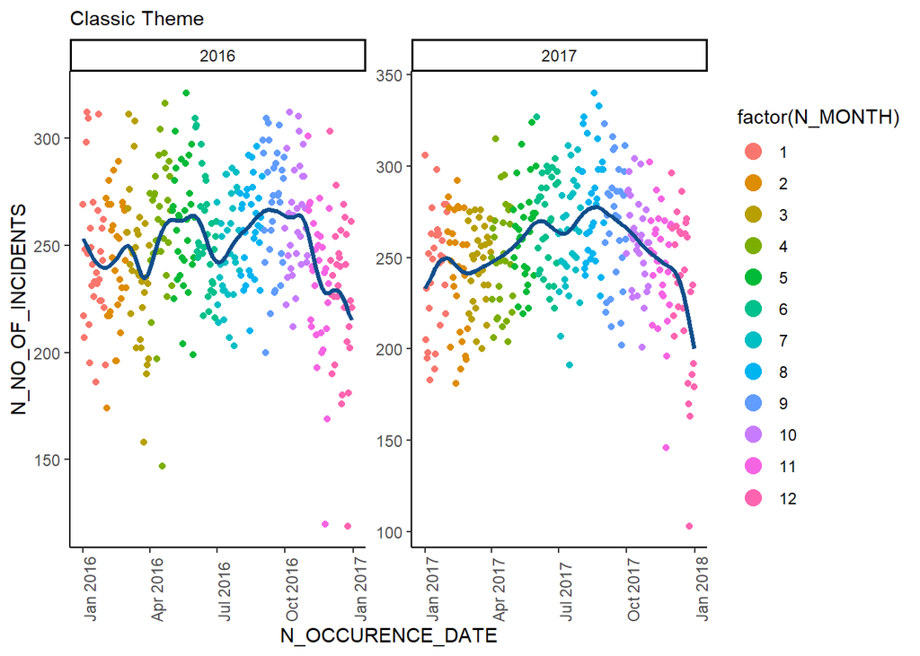

```r
crime.month.plot(2018, 2014)
```

The Change in Crime month wise is being shown for 2018 and 2014

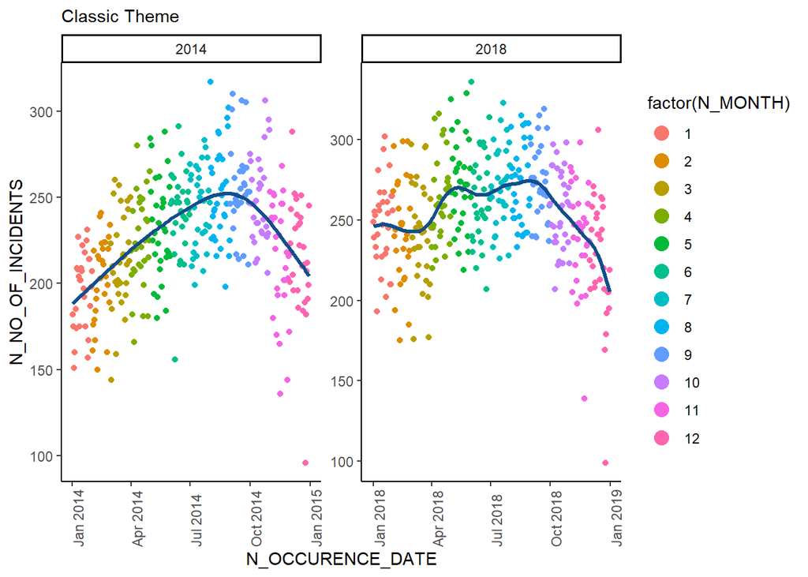

```r
#df.tmp <- df[df$N_YEAR==2018 | df$N_YEAR==2017 ,]

crime.monthly.plot <- function(df.rx, yr.vr){

  df.tmp <- df.rx[df.rx$N_YEAR==yr.vr ,]

  df.tmp <- df.tmp %>%
    group_by(N_YEAR,N_MONTH_FIG) %>%
    arrange(N_YEAR, N_MONTH_FIG)
  lbl <- paste("Month-", yr.vr)
  df.tmp <- df.tmp[order(df.tmp$N_MONTH_FIG),]
  df.tmp <- df.tmp[order(df.tmp$N_MONTH_FIG),]
  df.tmp$N_MONTH_FIG <- factor(df.tmp$N_MONTH_FIG, levels = df.tmp$N_MONTH_FIG)

  p9 <- ggplot(df.tmp, aes(x=factor(N_MONTH_FIG), y=incidents, fill=rainbow(12)))+
    geom_bar(stat='identity') +
    scale_fill_discrete(name = lbl, labels=c('Jan','Feb','Mar','Apr','May','Jun','Jul','Aug','Sep','Oct','Nov','Dec') )
  return(p9)

}

pandoc.header('9B: Change in Crimes Month Wise in 2017', 1, 'setext')
```

# 9B: Change in Crimes Month Wise in 2017

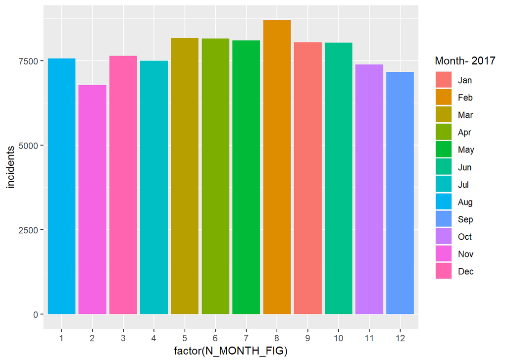

```r
crime.plot.yr1 <- crime.monthly.plot(df.stp10, 2017)
crime.plot.yr1
```

```r
pandoc.header('9C: Change in Crimes MonthWise in 2018', 1, 'setext')
```

# 9C: Change in Crimes MonthWise in 2018

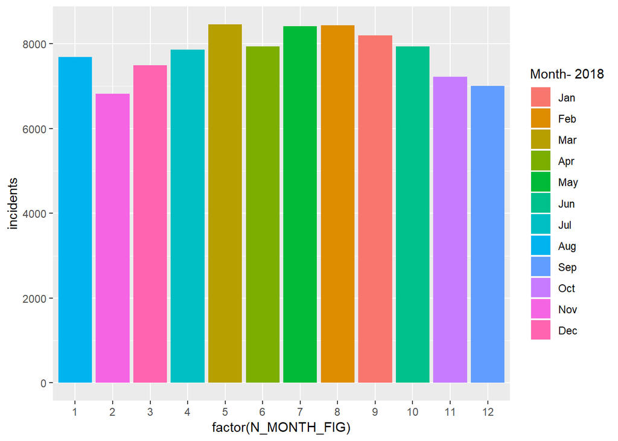

```r
crime.plot.yr2 <- crime.monthly.plot(df.stp10, 2018)
crime.plot.yr2
```

Step-10:Offeness and their Total Occurrences since 2014

```r
###############::NO-10::##################
pandoc.header('Step-10: Change in Crimes Month Wise and Year Wise', 1, 'setext')
```